# Twitter Sentiment Analysis: Marvel

## Table of Contents

## Sentiment Bar Chart

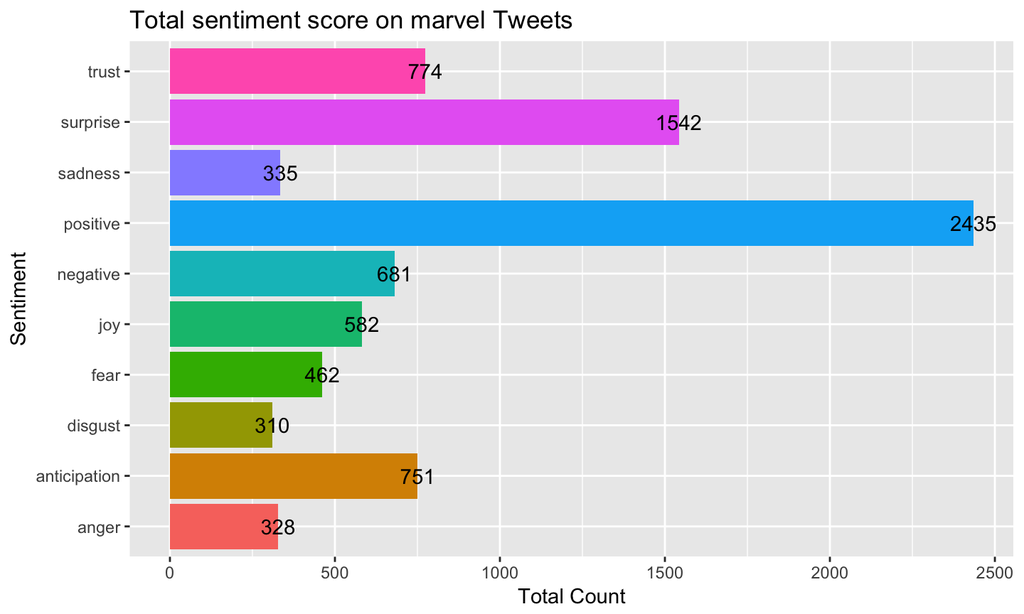

## Analysis:

The overall sentiment towards Marvel seems to be positive, followed by surprise, trust and anticipation. The barchart was created using the "Syuzhet Package". This package includes a function called get_nrc_sentiment() which takes in the tweets (in the form of a character vector) and outputs a data frame a data frame where each row represents a sentence from the original file. The columns include one for each emotion type as well as a positive or negative valence. The ten columns are as follows: "anger", "anticipation", "disgust", "fear", "joy", "sadness", "surprise", "trust", "negative" and "positive." After attaining the sentiments, I use ggplot to create a bar plot to visualize the sentiment and the count.

Thus, we can conclude that overall people have had a positive reaction to Marvel's new movie trailer. People are also surprised and in anticipation of the movie. This positive reaction indicates that the movie upon release will be successful.

## Line Plot

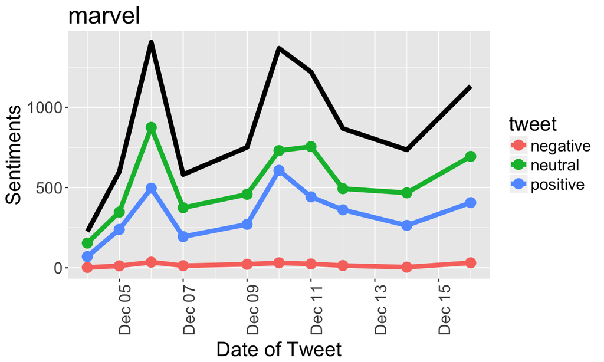

## Example tweets:

After gathering and cleaning the data, the function stores the collected tweets in a "marvel_stack.csv" file

```
##                                                                                                                                             text
## 1   RT @Todd_McFarlane: Some of the PERKS of being in the #comicbook business. A high grade VENOM variant cover. I helped co-create the charact…
## 2   RT @Le_sigh20: Decking the halls with @Marvel @MarvelStudios Christmas Loki. Can't have a real tree since my dog would eat it, so this is t…
## 3                                                                            marvel invisible girl naked 100 porn videos https://t.co/EFYlqDgHyg
## 4 RT @ComicBook: Its nostalgia overload in this fanmade recreation of the #AvengersInfinityWar trailer using only '90s #Marvel cartoons: \n\nht…
## 5                        #Marvel’s #AntManandTheWasp to be a rom com!?! \xed\xa0\xbd\xed\xb8\x81\xed\xa0\xbe\xed\xb4\xa3 https://t.co/o6EtmVlzRj
## 6   @CaptainFrugal @Marvel if cebulski even remotely considers this statement acceptable?\ni say let the dying beast of… https://t.co/BNDnzXnfsn
```

## Analysis:

The function score.sentiment then evaluates the tweets and determines if their sentiment is postivie, negative and neutral. This is done by scanning two files one filled with [positive words](http://ptrckprry.com/course/ssd/data/positive-words.txt) and the other with [negative words](http://ptrckprry.com/course/ssd/data/negative-words.txt). These scores are then saved in a "marvel _opin.csv" file. Then using ggplot, the scores are visualized on a line plot.

## Table

| Tweet | Created | Number |
| --- | --- | --- |
| Negative | 12/04/17 | 2 |
| Negative | 12/05/17 | 12 |
| Negative | 12/06/17 | 35 |
| Negative | 12/07/17 | 13 |
| Negative | 12/09/17 | 22 |
| Negative | 12/10/17 | 31 |
| Negative | 12/11/17 | 24 |
| Neutral | 12/04/17 | 154 |
| Neutral | 12/05/17 | 347 |
| Neutral | 12/06/17 | 875 |
| Neutral | 12/07/17 | 374 |
| Neutral | 12/09/17 | 458 |
| Neutral | 12/10/17 | 730 |
| Neutral | 12/11/17 | 748 |
| Neutral | 12/12/17 | 28 |
| Postive | 12/04/17 | 70 |
| Postive | 12/05/17 | 239 |
| Postive | 12/06/17 | 496 |
| Postive | 12/07/17 | 194 |
| Postive | 12/09/17 | 271 |
| Postive | 12/10/17 | 607 |
| Postive | 12/11/17 | 436 |
| Postive | 12/12/17 | 12 |

## Top hashtags associated with the Brand

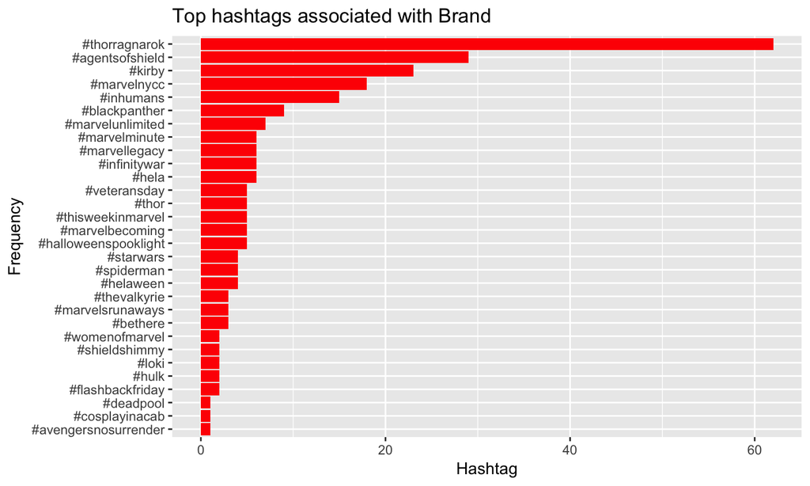

## Analysis:

This is a ggplot of the top hashtags associated with the Marvel brand. They are mainly all releated to the franchise. In the top ten we see "ThorRanganok", "blackpanther" and "Agentsof Shield" (The latest three Marvel movies). With nearly all of the produced hashtags being related to the franchise, we see the extent of Marvel's network. This shows that there are so many other tweets and hashtags being used on twitter that can be traced back to the brand, meaning there are so many users talking about Marvel on twitter. This was calculated by taking the searched and cleaned tweets and extracting other hashtags in the same tweet.

## Map (geocoded tweets with keyword "Marvel")

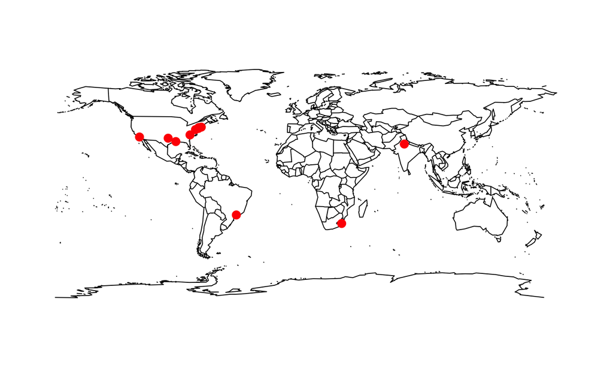

## Analysis:

Note: map takes a long-ish time to load since there are not a lot of geocoded tweets! Parsing through about 100,000 tweets

It seems to be that the majority of tweets are originating from the United States, especially from the larger urban and more populated regions and cities. The majoring of the other worldwide tweets also seems to be originating from major cities across the globe. We cannot make precise conclusions from the map since so few tweets are geocoded. It does seem fitting however that they are mainly originating from large cities, since they have a higher population. Additionally, it is hard to say if the reason why the majority of the tweets are from the USA is because Marvel's brand is more popular here in America or whether more users in America enable location on their tweets. This was created ggmap and geocoded tweets (using latitude and longitude).

## Tweets per Hour

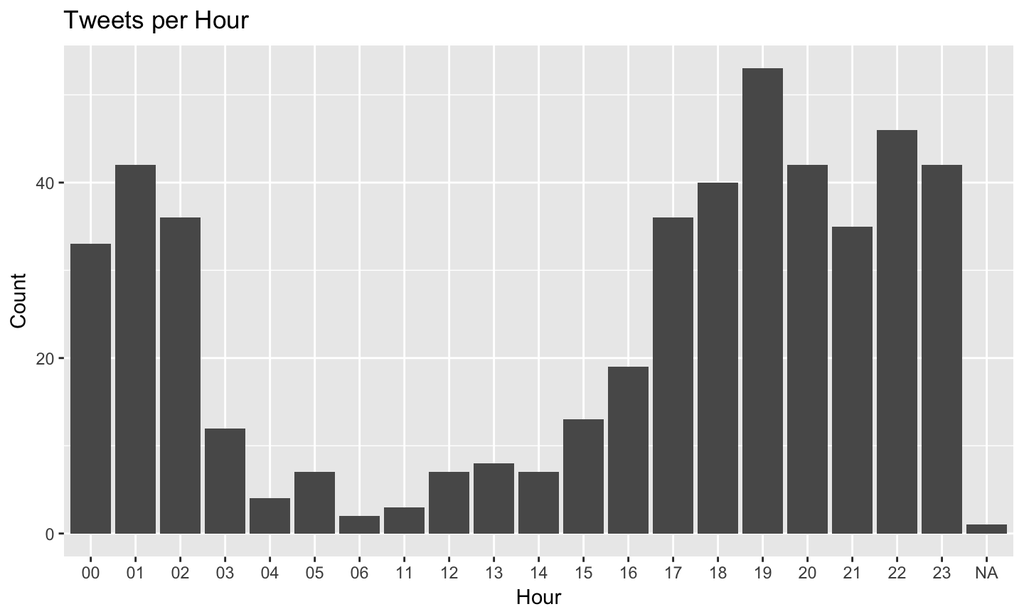

## Analysis:

This histogram shows at what time of the day are people tweeting about marvel! It seems that activity picks up in the evening around 5pm and continues till about 1am. This seems accurate as we can assume that most people would go on social media after their work day or at home in the night. The barplot was created using ggplot and the timestamp on the collected tweets.

## Top Tweeters of Hashtags

```
##                 User Tweets
## 964     Marvel_Bucky     30
## 678      Iona_Marvel     18
## 1264      RandyS0725     15
## 350   DailyXMenFacts     13
## 28          221Bcrow      9
## 1446  strange_marvel      9
## 1613   veloso_brunno      8
## 329      Cr0ss0ver_U      6
## 1334       sarahawks      6
## 280  CharmedbyBonnie      5
```

The above table shows the top 10 twitter users that tweet using the hashtag #marvel most frequently. This was created by searching all the collected tweets and seeing if a user has tweeted using #marvel more than once.

## Word Cloud:

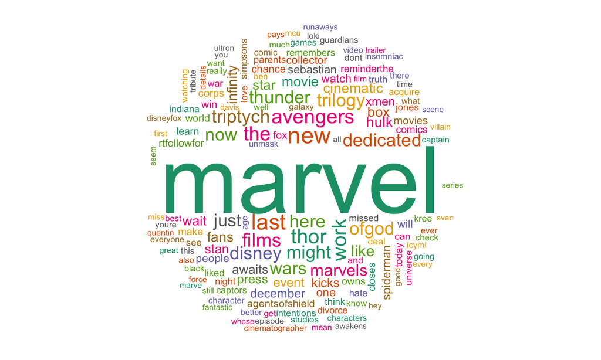

## Emoji Analysis (From hamdanazhar)

[figure not shown]

## Emoji table

```
##                                  name dens count rank
## 1                       birthday cake  3.9     3    4
## 2                              camera  3.9     3    5
## 3                                eyes  2.6     2    7
## 4              face with tears of joy  6.5     5    1
## 5                globe with meridians  5.2     4    2
## 6     grinning face with smiling eyes  2.6     2    6
## 7 smiling face with heart-shaped eyes  3.9     3    3
```